# COMPSCIX 415.2 Homework 5/Midterm

Larry Kubin

March 4, 2018

[Github Link](https://github.com/larrykubin/compscix-415-2-assignments)

## The tidyverse packages

### 1. Can you name which package is associated with each task below?

#### Plotting

ggplot2

#### Data munging/wrangling

dplyr

#### Reshaping (speading and gathering) data

tidyr

#### Importing/exporting data

readr

### 2. Now can you name two functions that you’ve used from each package that you listed above for these tasks?

#### Plotting

ggplot(), aes()

#### Data munging/wrangling

select(), filter()

#### Reshaping data

gather(), spread()

#### Importing/exporting data (note that readRDS and saveRDS are base R functions)

read_csv(), read_delim()

## R Basics

### 1. Fix this code with the fewest number of changes possible so it works:

The exclamation point was not a valid character in a variable name. A variable name can only consist of letters, numbers, and the dot and and underscore characters.

```r
My_data.name___is.too00ooLong <- c( 1 , 2 , 3 )
```

### 2. Fix this code so it works:

One of the values was missing a quotation mark. Also, vectors are created using the c() function. There was a capital C used to create the function, which caused an error.

```r
my_string <- c('has', 'an', 'error', 'in', 'it')
```

### 3. Look at the code below and comment on what happened to the values in the vector.

A vector can not have multiple types. Since a string is the most complex type in the vector, all values in the vector are coerced to strings.

```r
my_vector <- c(1, 2, '3', '4', 5)
my_vector
```

```
## [1] "1" "2" "3" "4" "5"
```

## Data Import / Export

### Import rail_trail.txt

```r
library(tidyverse)
rail_trail <- read_delim("rail_trail.txt", "|")
glimpse(rail_trail)
```

```
## Observations: 90
## Variables: 10
## $ hightemp   <int> 83, 73, 74, 95, 44, 69, 66, 66, 80, 79, 78, 65, 41,...
## $ lowtemp    <int> 50, 49, 52, 61, 52, 54, 39, 38, 55, 45, 55, 48, 49,...
## $ avgtemp    <dbl> 66.5, 61.0, 63.0, 78.0, 48.0, 61.5, 52.5, 52.0, 67....
## $ spring     <int> 0, 0, 1, 0, 1, 1, 1, 1, 0, 0, 0, 1, 1, 0, 0, 1, 0, ...
## $ summer     <int> 1, 1, 0, 1, 0, 0, 0, 0, 1, 1, 1, 0, 0, 0, 0, 0, 1, ...
## $ fall       <int> 0, 0, 0, 0, 0, 0, 0, 0, 0, 0, 0, 0, 0, 1, 1, 0, 0, ...
## $ cloudcover <dbl> 7.6, 6.3, 7.5, 2.6, 10.0, 6.6, 2.4, 0.0, 3.8, 4.1, ...
## $ precip     <dbl> 0.00, 0.29, 0.32, 0.00, 0.14, 0.02, 0.00, 0.00, 0.0...
## $ volume     <int> 501, 419, 397, 385, 200, 375, 417, 629, 533, 547, 4...
## $ weekday    <int> 1, 1, 1, 0, 1, 1, 1, 0, 0, 1, 1, 1, 1, 1, 1, 1, 0, ...
```

### Export the file into an R-specific format and reload it.

```r
saveRDS(rail_trail, file = "rail_trail.rds")

rail_trail_rds = readRDS(file = "rail_trail.rds")

glimpse(rail_trail_rds)
```

```
## Observations: 90
## Variables: 10
## $ hightemp   <int> 83, 73, 74, 95, 44, 69, 66, 66, 80, 79, 78, 65, 41,...
## $ lowtemp    <int> 50, 49, 52, 61, 52, 54, 39, 38, 55, 45, 55, 48, 49,...
## $ avgtemp    <dbl> 66.5, 61.0, 63.0, 78.0, 48.0, 61.5, 52.5, 52.0, 67....
## $ spring     <int> 0, 0, 1, 0, 1, 1, 1, 1, 0, 0, 0, 1, 1, 0, 0, 1, 0, ...
## $ summer     <int> 1, 1, 0, 1, 0, 0, 0, 0, 1, 1, 1, 0, 0, 0, 0, 0, 1, ...
## $ fall       <int> 0, 0, 0, 0, 0, 0, 0, 0, 0, 0, 0, 0, 0, 1, 1, 0, 0, ...
## $ cloudcover <dbl> 7.6, 6.3, 7.5, 2.6, 10.0, 6.6, 2.4, 0.0, 3.8, 4.1, ...
## $ precip     <dbl> 0.00, 0.29, 0.32, 0.00, 0.14, 0.02, 0.00, 0.00, 0.0...
## $ volume     <int> 501, 419, 397, 385, 200, 375, 417, 629, 533, 547, 4...
## $ weekday    <int> 1, 1, 1, 0, 1, 1, 1, 0, 0, 1, 1, 1, 1, 1, 1, 1, 0, ...
```

## Visualization

#### 2. Side-by-side circles do not clearly express percentage data. This could have been easily expressed by a table or a stacked bar chart.

#### 3. The numbers should have a percentage sign next to them. Without it, they look like quantity/counts at first glance.

### 2. Reproduce this graphic using the diamonds data set.

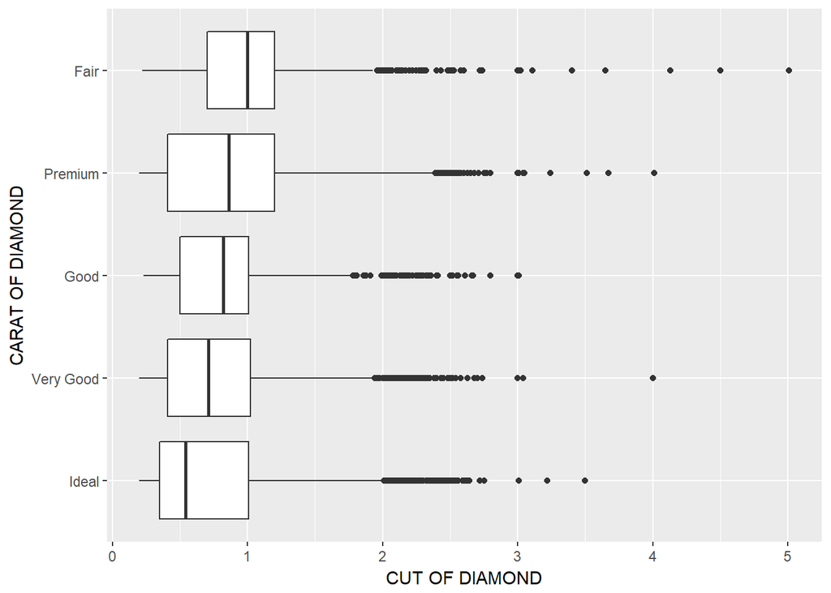

```r
ggplot(data = diamonds, mapping = aes(x = reorder(cut, carat), y = carat)) + geom_boxplot() + xlab("CARAT OF DIAMOND") + ylab("CUT OF DIAMOND") + coord_flip()
```

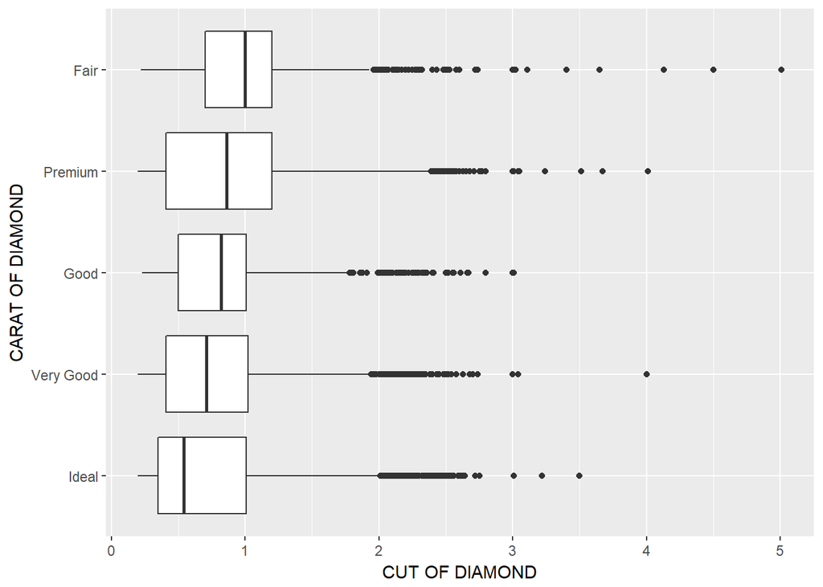

```r
ggplot(data = diamonds, mapping = aes(x = reorder(cut, carat), y = carat), position="dodge") + geom_boxplot() + xlab("CARAT OF DIAMOND") + ylab("CUT OF DIAMOND") + coord_flip()
```

## Data munging and wrangling (6 points)

#### 1. Is this data “tidy”? If yes, leave it alone and go to the next problem. If no, make it tidy. Note: this data set is called table2 and is available in the tidyverse package. It should be ready for you to use after you’ve loaded the tidyverse package.

The data is not tidy. Cases and population need to be there own columns with only their own values. This can be accomplished using the spread() function.

```r
spread(table2, type, count)
```

```
## # A tibble: 6 x 4
##   country      year  cases population
## * <chr>       <int>  <int>      <int>
## 1 Afghanistan  1999    745   19987071
## 2 Afghanistan  2000   2666   20595360
## 3 Brazil       1999  37737  172006362
## 4 Brazil       2000  80488  174504898
## 5 China        1999 212258 1272915272
## 6 China        2000 213766 1280428583
```

#### 2. Create a new column in the diamonds data set called price_per_carat that shows the price of each diamond per carat (hint: divide). Only show me the code, not the output.

```r
diamonds$price_per_carat <- diamonds$price / diamonds$carat
```

#### 3. For each cut of diamond in the diamonds data set, how many diamonds, and what proportion, have a price > 10000 and a carat < 1.5? There are several ways to get to an answer, but your solution must use the data wrangling verbs from the tidyverse in order to get credit.

##### a. Do the results make sense? Why?

834 diamonds and 1.5%

```r
nrow(filter(diamonds, price > 10000 & carat < 1.5))
```

```
## [1] 834
```

```r
(nrow(filter(diamonds, price > 10000 & carat < 1.5)) / nrow(diamonds)) * 100
```

```
## [1] 1.546162
```

##### b. Do we need to be wary of any of these numbers? Why?

```r
filter(diamonds, price > 10000 & carat < 1.5)
```

```
## # A tibble: 834 x 11
##    carat cut       color clarity depth table price     x     y     z
##    <dbl> <ord>     <ord> <ord>   <dbl> <dbl> <int> <dbl> <dbl> <dbl>
##  1  1.03 Ideal     E     VVS2     60.6  59.0 10003  6.50  6.53  3.95
##  2  1.23 Very Good G     VVS2     60.6  55.0 10004  6.93  7.02  4.23
##  3  1.25 Ideal     F     VS2      61.6  55.0 10006  6.93  6.96  4.28
##  4  1.21 Very Good F     VS1      62.3  58.0 10009  6.76  6.85  4.24
##  5  1.01 Fair      D     SI2      64.6  58.0 10011  6.25  6.20  4.02
##  6  1.05 Ideal     F     VVS2     60.5  55.0 10011  6.67  6.58  4.01
##  7  1.35 Premium   G     VS1      62.1  59.0 10012  7.06  7.02  4.37
##  8  1.13 Ideal     F     VS1      60.9  57.0 10016  6.73  6.76  4.11
##  9  1.21 Premium   F     VS1      62.6  59.0 10018  6.81  6.76  4.25
## 10  1.01 Very Good F     VVS1     62.9  57.0 10019  6.35  6.41  4.01
## # ... with 824 more rows, and 1 more variable: price_per_carat <dbl>
```

## EDA

Take a look at the txhousing data set that is included with the ggplot2 package and answer these questions:

```r
glimpse(txhousing)
```

```
## Observations: 8,602
## Variables: 9
## $ city      <chr> "Abilene", "Abilene", "Abilene", "Abilene", "Abilene...
## $ year      <int> 2000, 2000, 2000, 2000, 2000, 2000, 2000, 2000, 2000...
## $ month     <int> 1, 2, 3, 4, 5, 6, 7, 8, 9, 10, 11, 12, 1, 2, 3, 4, 5...
## $ sales     <dbl> 72, 98, 130, 98, 141, 156, 152, 131, 104, 101, 100, ...
## $ volume    <dbl> 5380000, 6505000, 9285000, 9730000, 10590000, 139100...
## $ median    <dbl> 71400, 58700, 58100, 68600, 67300, 66900, 73500, 750...
## $ listings  <dbl> 701, 746, 784, 785, 794, 780, 742, 765, 771, 764, 72...
## $ inventory <dbl> 6.3, 6.6, 6.8, 6.9, 6.8, 6.6, 6.2, 6.4, 6.5, 6.6, 6....
## $ date      <dbl> 2000.000, 2000.083, 2000.167, 2000.250, 2000.333, 20...
```

#### 1. During what time period is this data from?

The time period is January 2000 through July 2015.

```r
# get min month for min year
min(txhousing$year)
```

```
## [1] 2000
```

```r
min_year_houses <- filter(txhousing, year == 2000)
min(min_year_houses$month);
```

```
## [1] 1
```

```r
# get max month for max year
max(txhousing$year)
```

```
## [1] 2015
```

```r
max_year_houses <- filter(txhousing, year == 2015)
max(max_year_houses$month);
```

```
## [1] 7
```

#### 2. How many cities are represented?

There are 46 distinct cities represented.

```r
distinct(txhousing, city)
```

```
## # A tibble: 46 x 1
##    city
##    <chr>
##  1 Abilene
##  2 Amarillo
##  3 Arlington
##  4 Austin
##  5 Bay Area
##  6 Beaumont
##  7 Brazoria County
##  8 Brownsville
##  9 Bryan-College Station
## 10 Collin County
## # ... with 36 more rows
```

#### 3. Which city, month and year had the highest number of sales?

Houston had the greatest number of sales in July of 2015.

```r
ordered <- arrange(txhousing, desc(sales))
print(ordered)
```

```
## # A tibble: 8,602 x 9
##    city     year month sales     volume median listings inventory  date
##    <chr>   <int> <int> <dbl>      <dbl>  <dbl>    <dbl>     <dbl> <dbl>
##  1 Houston  2015     7  8945 2568156780 217600    23875      3.40  2016
##  2 Houston  2006     6  8628 1795898108 155200    36281      5.60  2006
##  3 Houston  2013     7  8468 2168720825 187800    21497      3.30  2014
##  4 Houston  2015     6  8449 2490238594 222400    22311      3.20  2015
##  5 Houston  2013     5  8439 2121508529 186100    20526      3.30  2013
##  6 Houston  2014     6  8391 2342443127 211200    19725      2.90  2014
##  7 Houston  2014     7  8391 2278932511 199700    20214      3.00  2014
##  8 Houston  2014     8  8167 2195184825 202400    20007      2.90  2015
##  9 Houston  2013     8  8155 2083377894 186700    21366      3.30  2014
## 10 Houston  2006     5  8040 1602621368 151200    35398      5.50  2006
## # ... with 8,592 more rows
```

#### 4. What kind of relationship do you think exists between the number of listings and the number of sales? Check your assumption and show your work.

If there are more listings there should be more sales. We can see this is the case by creating a simple scatterplot of listings vs. sales. You can see as the number of listings goes up on the X axis, the number of sales trends upwards on the Y axis.

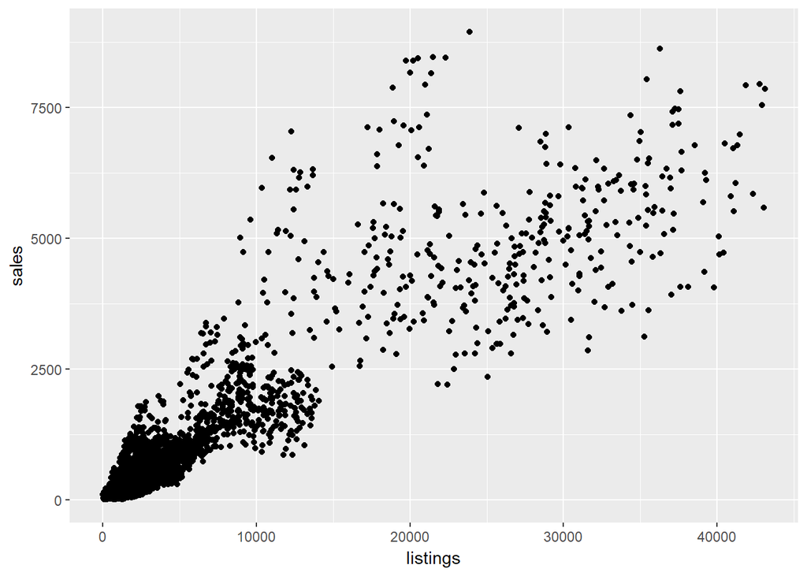

```r
ggplot(txhousing, aes(x=listings, y=sales)) + geom_point()
```

```r
filter(txhousing, is.na(sales)) %>% count(city)
```

```
## # A tibble: 20 x 2
##    city                   n
##    <chr>              <int>
##  1 Brazoria County       14
##  2 Brownsville            2
##  3 Corpus Christi         1
##  4 Galveston              1
##  5 Harlingen             25
##  6 Kerrville            104
##  7 Killeen-Fort Hood      1
##  8 Laredo                36
##  9 Longview-Marshall     12
## 10 Lubbock                1
## 11 McAllen                2
## 12 Midland               75
## 13 Nacogdoches           11
## 14 Odessa                72
## 15 Port Arthur            2
## 16 San Marcos            46
## 17 South Padre Island   116
## 18 Temple-Belton         11
## 19 Texarkana             17
## 20 Waco                  19
```

#### 6. Looking at only the cities and months with greater than 500 sales:

##### a. Are the distributions of the median sales price (column name median), when grouped by city, different? The same? Show your work.

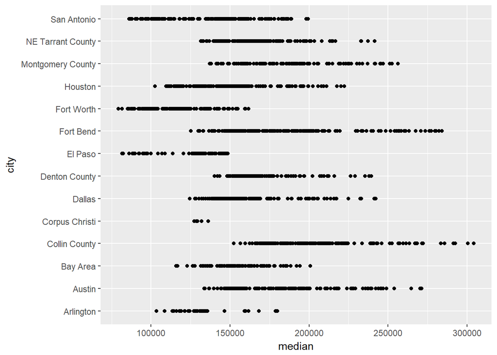

```r
salesgt500 <- filter(txhousing, sales > 500)
saleslt500 <- filter(txhousing, sales < 500)

ggplot(salesgt500, aes(x=median, y=city)) + geom_point()
```

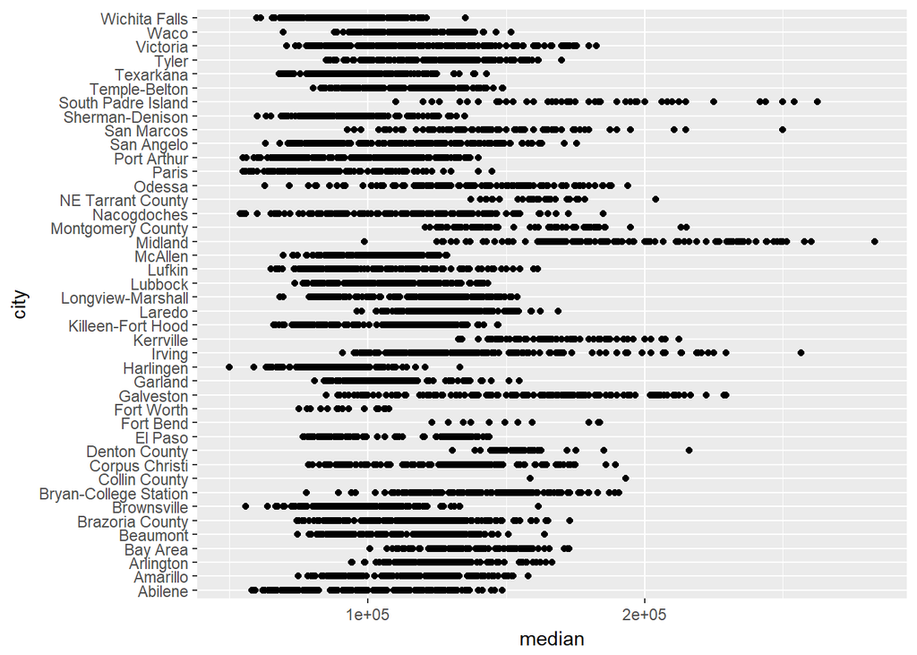

```r
ggplot(saleslt500, aes(x=median, y=city)) + geom_point()
```

##### c. Why might we want to filter out all cities and months with sales less than 500?

These cities have less data points and would be less accurate.